# Male and female suicide rates

The present notebook is presenting some summaries and plots based on the two files from the Gapminder website:

- [Suicide rates for men from WHO (per 100,000 people)](https://spreadsheets.google.com/pub?key=tB8ge4cxd8TL7yIV4ALm5NA&output=xls)
- [Suicide rates for women from WHO (per 100,000 people)](https://spreadsheets.google.com/pub?key=tUD6kmYmB_Bp85SRdEn1Krg&output=xls)

I converted both files to CSV named suicide_male.csv and suicide_female.csv. I load both the sources into R:

```r
suicide_male <- read.csv("suicide_male.csv", sep = ",")
```

```r
suicide_female <- read.csv("suicide_female.csv", sep = ",")
```

The first thing is to print out fragments of the data and some introductory statistics, in order to become acquainted with the datasets:

```r
head(suicide_male)
```

```
##   Suicide.among.men..per.100.000..age.adjusted X1950 X1951 X1952 X1953
## 1                                  Afghanistan    NA    NA    NA    NA
## 2                                      Albania    NA    NA    NA    NA
## 3                                      Algeria    NA    NA    NA    NA
## 4                                      Andorra    NA    NA    NA    NA
## 5                                       Angola    NA    NA    NA    NA
## 6                          Antigua and Barbuda    NA    NA    NA    NA
##   X1954 X1955 X1956 X1957 X1958 X1959 X1960 X1961 X1962 X1963 X1964 X1965
## 1    NA    NA    NA    NA    NA    NA    NA    NA    NA    NA    NA    NA
## 2    NA    NA    NA    NA    NA    NA    NA    NA    NA    NA    NA    NA
## 3    NA    NA    NA    NA    NA    NA    NA    NA    NA    NA    NA    NA
## 4    NA    NA    NA    NA    NA    NA    NA    NA    NA    NA    NA    NA
## 5    NA    NA    NA    NA    NA    NA    NA    NA    NA    NA    NA    NA
## 6    NA    NA    NA    NA    NA    NA    NA    NA    NA    NA    NA    NA
##   X1966 X1967 X1968 X1969 X1970 X1971 X1972 X1973 X1974 X1975 X1976 X1977
```

[output cut: 27 more lines]

```r
summary(suicide_male)
```

```
##  Suicide.among.men..per.100.000..age.adjusted     X1950
##  Afghanistan        :  1                      Min.   : 4.258
##  Albania            :  1                      1st Qu.:11.285
##  Algeria            :  1                      Median :13.201
##  Andorra            :  1                      Mean   :14.667
##  Angola             :  1                      3rd Qu.:16.807
##  Antigua and Barbuda:  1                      Max.   :31.452
##  (Other)            :192                      NA's   :188
##      X1951            X1952            X1953            X1954
##  Min.   : 4.003   Min.   : 3.379   Min.   : 1.927   Min.   : 3.258
##  1st Qu.: 9.673   1st Qu.: 9.616   1st Qu.:10.189   1st Qu.:10.229
##  Median :11.812   Median :15.443   Median :14.081   Median :14.767
##  Mean   :15.042   Mean   :16.849   Mean   :17.170   Mean   :17.617
##  3rd Qu.:17.899   3rd Qu.:23.527   3rd Qu.:25.090   3rd Qu.:24.749
##  Max.   :31.320   Max.   :32.923   Max.   :32.949   Max.   :34.312
##  NA's   :182      NA's   :179      NA's   :177      NA's   :176
##      X1955            X1956            X1957            X1958
##  Min.   : 2.442   Min.   : 2.222   Min.   : 1.509   Min.   : 3.744
##  1st Qu.:10.913   1st Qu.:12.503   1st Qu.:10.881   1st Qu.:10.885
##  Median :15.493   Median :15.957   Median :15.775   Median :16.097
##  Mean   :17.518   Mean   :18.202   Mean   :17.994   Mean   :17.996
##  3rd Qu.:24.424   3rd Qu.:27.581   3rd Qu.:27.505   3rd Qu.:24.582
##  Max.   :35.882   Max.   :40.358   Max.   :38.269   Max.   :36.833
##  NA's   :169      NA's   :169      NA's   :169      NA's   :169
##      X1959            X1960           X1961            X1962
##  Min.   : 3.957   Min.   : 3.81   Min.   : 3.787   Min.   : 2.988
##  1st Qu.:10.962   1st Qu.:10.44   1st Qu.: 8.615   1st Qu.: 8.036
##  Median :16.276   Median :15.62   Median :15.592   Median :14.440
##  Mean   :18.009   Mean   :17.54   Mean   :16.495   Mean   :16.196
##  3rd Qu.:23.972   3rd Qu.:23.62   3rd Qu.:22.700   3rd Qu.:22.869
##  Max.   :37.932   Max.   :35.66   Max.   :36.410   Max.   :37.739
##  NA's   :169      NA's   :168     NA's   :167      NA's   :166
##      X1963            X1964            X1965            X1966
##  Min.   : 3.790   Min.   : 3.540   Min.   : 3.148   Min.   : 3.493
##  1st Qu.: 8.185   1st Qu.: 8.268   1st Qu.: 9.211   1st Qu.: 9.711
##  Median :15.928   Median :14.878   Median :16.654   Median :15.591
##  Mean   :16.169   Mean   :16.276   Mean   :16.436   Mean   :16.597
##  3rd Qu.:23.226   3rd Qu.:23.709   3rd Qu.:22.236   3rd Qu.:22.047
##  Max.   :37.487   Max.   :40.131   Max.   :41.366   Max.   :40.384
##  NA's   :163      NA's   :162      NA's   :163      NA's   :162
```

[output cut: 65 more lines]

```
##  Min.   : 0.000   Min.   : 0.000   Min.   : 0.000   Min.   : 1.756
##  1st Qu.: 9.452   1st Qu.: 8.631   1st Qu.: 9.734   1st Qu.:10.472
##  Median :18.415   Median :16.839   Median :16.709   Median :17.884
##  Mean   :20.072   Mean   :18.747   Mean   :19.242   Mean   :20.789
##  3rd Qu.:23.914   3rd Qu.:23.391   3rd Qu.:23.072   3rd Qu.:24.402
##  Max.   :73.372   Max.   :75.079   Max.   :71.129   Max.   :74.296
##  NA's   :133      NA's   :133      NA's   :136      NA's   :139
##      X2003            X2004
##  Min.   : 3.328   Min.   : 0.000
##  1st Qu.:10.964   1st Qu.: 6.884
##  Median :16.523   Median :12.400
##  Mean   :20.882   Mean   :14.228
##  3rd Qu.:24.705   3rd Qu.:18.629
##  Max.   :67.592   Max.   :63.309
##  NA's   :143      NA's   :5
```

```r
head(suicide_female)
```

```
##   Suicide.women.age.adjusted X1950 X1951 X1952 X1953 X1954 X1955 X1956
## 1                Afghanistan    NA    NA    NA    NA    NA    NA    NA
## 2                    Albania    NA    NA    NA    NA    NA    NA    NA
## 3                    Algeria    NA    NA    NA    NA    NA    NA    NA
## 4                    Andorra    NA    NA    NA    NA    NA    NA    NA
## 5                     Angola    NA    NA    NA    NA    NA    NA    NA
## 6        Antigua and Barbuda    NA    NA    NA    NA    NA    NA    NA
##   X1957 X1958 X1959 X1960 X1961 X1962 X1963 X1964 X1965 X1966 X1967 X1968
## 1    NA    NA    NA    NA    NA    NA    NA    NA    NA    NA    NA    NA
## 2    NA    NA    NA    NA    NA    NA    NA    NA    NA    NA    NA    NA
## 3    NA    NA    NA    NA    NA    NA    NA    NA    NA    NA    NA    NA
## 4    NA    NA    NA    NA    NA    NA    NA    NA    NA    NA    NA    NA
## 5    NA    NA    NA    NA    NA    NA    NA    NA    NA    NA    NA    NA
## 6    NA    NA    NA    NA    NA    NA    NA    NA    NA    NA    NA    NA
##   X1969 X1970 X1971 X1972 X1973 X1974 X1975 X1976 X1977 X1978 X1979 X1980
```

[output cut: 27 more lines]

```r
summary(suicide_female)
```

```
##        Suicide.women.age.adjusted     X1950             X1951
##  Afghanistan        :  1          Min.   : 0.8519   Min.   : 1.148
##  Albania            :  1          1st Qu.: 3.9289   1st Qu.: 3.281
##  Algeria            :  1          Median : 4.7596   Median : 4.568
##  Andorra            :  1          Mean   : 5.7157   Mean   : 5.931
##  Angola             :  1          3rd Qu.: 5.2783   3rd Qu.: 5.992
##  Antigua and Barbuda:  1          Max.   :18.5910   Max.   :17.542
##  (Other)            :192          NA's   :188       NA's   :182
##      X1952             X1953             X1954             X1955
##  Min.   : 0.8796   Min.   : 0.3979   Min.   : 0.7037   Min.   : 0.3915
##  1st Qu.: 3.5925   1st Qu.: 3.7396   1st Qu.: 3.5755   1st Qu.: 2.9516
##  Median : 5.0831   Median : 5.4561   Median : 5.6123   Median : 5.3187
##  Mean   : 6.2225   Mean   : 6.3617   Mean   : 6.3943   Mean   : 6.3852
##  3rd Qu.: 6.3471   3rd Qu.: 8.1118   3rd Qu.: 7.5968   3rd Qu.: 8.4874
##  Max.   :17.7080   Max.   :18.7084   Max.   :19.7812   Max.   :20.9291
##  NA's   :179       NA's   :177       NA's   :176       NA's   :169
##      X1956            X1957             X1958            X1959
##  Min.   : 0.334   Min.   : 0.2548   Min.   : 1.091   Min.   : 1.154
##  1st Qu.: 3.441   1st Qu.: 2.7941   1st Qu.: 3.268   1st Qu.: 3.472
##  Median : 5.729   Median : 5.6789   Median : 5.405   Median : 5.790
##  Mean   : 6.603   Mean   : 6.4650   Mean   : 6.546   Mean   : 6.527
##  3rd Qu.: 9.487   3rd Qu.: 9.3591   3rd Qu.: 9.759   3rd Qu.: 8.416
##  Max.   :21.072   Max.   :20.5632   Max.   :21.983   Max.   :19.978
##  NA's   :169      NA's   :169       NA's   :169      NA's   :169
##      X1960            X1961             X1962             X1963
##  Min.   : 1.267   Min.   : 0.8261   Min.   : 0.7359   Min.   : 0.3511
##  1st Qu.: 3.372   1st Qu.: 3.0082   1st Qu.: 2.7799   1st Qu.: 2.7735
##  Median : 5.916   Median : 4.5473   Median : 5.3369   Median : 4.7487
##  Mean   : 6.536   Mean   : 6.0684   Mean   : 5.9410   Mean   : 5.9380
##  3rd Qu.: 8.609   3rd Qu.: 8.1687   3rd Qu.: 8.9745   3rd Qu.: 8.7802
##  Max.   :19.146   Max.   :17.7909   Max.   :15.5424   Max.   :15.2656
##  NA's   :168      NA's   :167       NA's   :166       NA's   :163
##      X1964             X1965             X1966             X1967
##  Min.   : 0.6879   Min.   : 0.4481   Min.   : 0.3508   Min.   : 0.4273
##  1st Qu.: 2.8424   1st Qu.: 3.0714   1st Qu.: 3.3965   1st Qu.: 2.9156
##  Median : 5.4108   Median : 5.9757   Median : 5.5454   Median : 5.4781
##  Mean   : 6.1415   Mean   : 6.2503   Mean   : 6.4322   Mean   : 6.1510
##  3rd Qu.: 9.4928   3rd Qu.: 9.1469   3rd Qu.: 9.6702   3rd Qu.:10.2097
##  Max.   :15.1147   Max.   :15.8135   Max.   :15.6408   Max.   :15.6902
##  NA's   :162       NA's   :163       NA's   :162       NA's   :161
```

[output cut: 65 more lines]

```
##  Min.   : 0.03989   Min.   : 0.6872   Min.   : 0.8555   Min.   : 0.9492
##  1st Qu.: 2.50528   1st Qu.: 2.4437   1st Qu.: 2.9242   1st Qu.: 3.0709
##  Median : 4.43547   Median : 4.8133   Median : 4.6758   Median : 4.4902
##  Mean   : 4.83422   Mean   : 4.8077   Mean   : 5.0099   Mean   : 4.9488
##  3rd Qu.: 7.47449   3rd Qu.: 6.8728   3rd Qu.: 6.9994   3rd Qu.: 6.7207
##  Max.   :13.98588   Max.   :12.0488   Max.   :10.1242   Max.   :12.4574
##  NA's   :137        NA's   :139       NA's   :139       NA's   :143
##      X2004
##  Min.   : 0.1078
##  1st Qu.: 2.9528
##  Median : 5.0510
##  Mean   : 5.5662
##  3rd Qu.: 7.1703
##  Max.   :26.9730
##  NA's   :8
```

```r
new <- data.frame("country" = suicide_male$Suicide.among.men..per.100.000..age.adjusted,
                  "female" = suicide_female$X2004,
                  "male" = suicide_male$X2004)
```

Next, we print summary of the data:

```r
summary(new)
```

```
##                 country        female             male
##  Afghanistan        :  1   Min.   : 0.1078   Min.   : 0.000
##  Albania            :  1   1st Qu.: 2.9528   1st Qu.: 6.884
##  Algeria            :  1   Median : 5.0510   Median :12.400
##  Andorra            :  1   Mean   : 5.5662   Mean   :14.228
##  Angola             :  1   3rd Qu.: 7.1703   3rd Qu.:18.629
##  Antigua and Barbuda:  1   Max.   :26.9730   Max.   :63.309
##  (Other)            :192   NA's   :8         NA's   :5
```

In the introductory statistics, we already notice, that the mean and median for male suicide is far larger than the mean and median of female suicide, an observation which would go in hand with theoretical observations on suicide by authors such as Emile Durkheim.

To investigate this phenomenon further, let us plot the data:

```r
library(ggplot2)
```

```r
p1 <- ggplot(aes(female), data = new) +
  geom_histogram(binwidth = 2) +
  scale_x_continuous(breaks = seq(0, 60, 5), limits = c(0, 60)) +
  scale_y_continuous(breaks = seq(0, 50, 5), limits = c(0, 50))
```

```r
p2 <- ggplot(aes(male), data = new) +
  geom_histogram(binwidth = 2) +
  scale_x_continuous(breaks = seq(0, 60, 5), limits = c(0, 60)) +
  scale_y_continuous(breaks = seq(0, 50, 5), limits = c(0, 50))
```

```r
library(gridExtra)
```

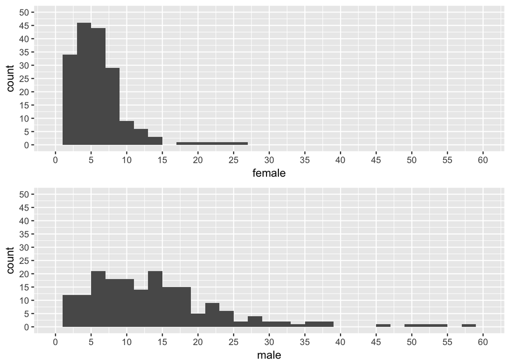

```r
grid.arrange(p1, p2, ncol = 1)
```

The above observations could be gleamed from the summaries of the data as well, and as such, are not particularly revealing.

What could bring some clarity on the relation between these two counts could be Pearson’s correlation.

```r
with(new, cor.test(male, female))
```

```
##
##  Pearson's product-moment correlation
##
## data:  male and female
## t = 9.7689, df = 188, p-value < 2.2e-16
## alternative hypothesis: true correlation is not equal to 0
## 95 percent confidence interval:
##  0.4773362 0.6674788
## sample estimates:
##       cor
## 0.5802606
```

Pearson’t correlation between the two counts stands at 0.58, which marks quite a significant correlation. While I might be mistaken (the dataset is quite unlike the other sets I have been working on, in its delimited information), this might indicate, that higher female suicide rate indicates higher male suicide rate. Let us follow this trope, and plot the two variables against each other:

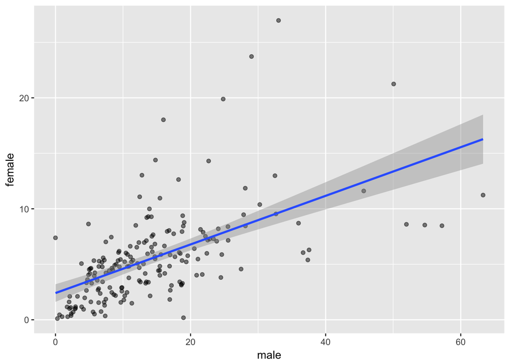

```r
ggplot(aes(x = male, y = female), data = new) +
  geom_point(alpha = 0.5) +
  geom_smooth(method = "lm")
```

The scatterplot does indeed indicate a definite relation between the two. While the male suicide rate is generally higher than female suicide rate, high percentage of one indicates high percentage of the other.

The following are some variations for the plot above, introducing some aesthetic changes:

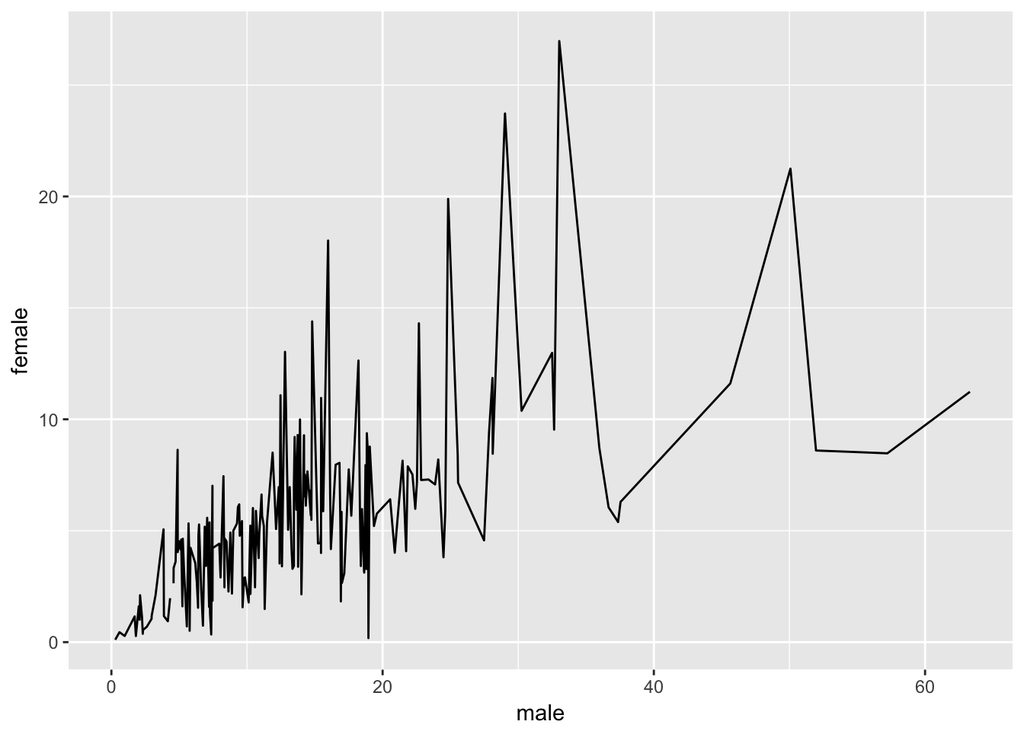

```r
ggplot(aes(x = male, y = female), data = new) +
  geom_line()
```

geom_line appears far less informative than the above visualizations.

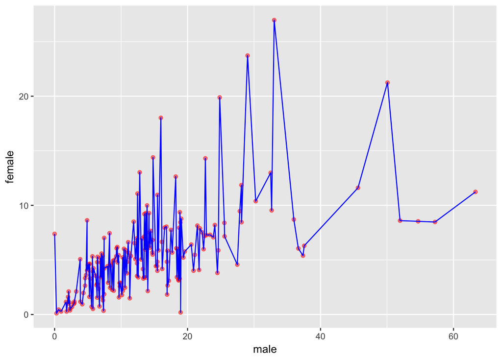

```r
ggplot(aes(x = male, y = female), data = new) +
  geom_point(alpha = 0.5,
             color = "red") +
  geom_line(stat = "summary", fun.y = mean, color = "blue")
```

Pretty much the same informational value, and not very visually impressive…